# Volunteer Summary - MMH

## Demographic information

| Characteristic | N = 281 |
| --- | --- |
| age | 42.28 ± 14.85 (21 - 70) |
| gender |  |
| female | 24 (86%) |
| male | 4 (14%) |
| occupation |  |
| civil | 1 (3.6%) |
| clerk | 6 (21%) |
| homemaker | 5 (18%) |
| manager | 3 (11%) |
| other | 3 (11%) |
| professional | 3 (11%) |
| retired | 2 (7.1%) |
| service | 1 (3.6%) |
| student | 3 (11%) |
| unemploy | 1 (3.6%) |
| marital |  |
| divorced | 2 (7.1%) |
| married | 9 (32%) |
| single | 17 (61%) |
| education |  |
| primary | 0 (0%) |
| secondary | 7 (25%) |
| post-secondary | 3 (11%) |
| university | 18 (64%) |
| family_income |  |
| 0_10000 | 4 (14%) |
| 10001_20000 | 6 (21%) |
| 20001_30000 | 4 (14%) |
| 30001_40000 | 5 (18%) |
| 40000_above | 9 (32%) |
| religion |  |
| buddhism | 1 (3.6%) |
| catholic | 3 (11%) |
| christianity | 9 (32%) |
| nil | 13 (46%) |
| other | 1 (3.6%) |
| taoism | 1 (3.6%) |
| source |  |
| bokss | 14 (50%) |
| facebook | 2 (7.1%) |
| other | 6 (21%) |
| refresh | 6 (21%) |
| previous_volunteer |  |
| yes_beyong_12_month | 12 (43%) |
| yes_within_12_month | 16 (57%) |
| previous_volunteer_r |  |
| yes | 28 (100%) |
| current_volunteer |  |
| no | 11 (39%) |
| yes | 17 (61%) |
| number_volunteer_r | 1.00 ± 1.05 (0 - 3) |

1Mean ± SD (Range); n (%)

## Measurement

| Characteristic | 1st, N = 281 | 2nd, N = 271 |
| --- | --- | --- |
| sets | 19.75 ± 2.20 (15 - 25) | 19.52 ± 2.23 (14 - 25) |
| setv | 11.11 ± 1.71 (8 - 15) | 11.30 ± 1.88 (7 - 15) |
| maks | 44.25 ± 3.50 (38 - 54) | 44.93 ± 3.86 (36 - 54) |
| ibs | 15.36 ± 2.08 (9 - 20) | 15.93 ± 1.41 (13 - 20) |
| ers_e | 12.25 ± 1.04 (10 - 15) | 12.26 ± 1.26 (10 - 15) |
| ers_r | 11.29 ± 1.44 (8 - 15) | 11.52 ± 1.42 (9 - 15) |
| pss_pa | 45.36 ± 4.42 (31 - 53) | 44.19 ± 3.93 (36 - 50) |
| pss_ps | 24.43 ± 6.61 (12 - 41) | 24.15 ± 6.86 (13 - 38) |
| pss | 42.07 ± 10.23 (24 - 67) | 42.96 ± 10.07 (27 - 61) |
| rki_responsible | 21.39 ± 3.07 (14 - 27) | 21.30 ± 3.35 (16 - 28) |
| rki_nonlinear | 13.29 ± 2.27 (8 - 17) | 13.67 ± 3.15 (7 - 20) |
| rki_peer | 19.96 ± 1.99 (17 - 25) | 20.33 ± 2.27 (15 - 25) |
| rki_expect | 4.86 ± 1.04 (3 - 7) | 5.07 ± 1.11 (3 - 8) |
| rki | 59.50 ± 4.16 (52 - 67) | 60.37 ± 5.25 (51 - 70) |
| raq_possible | 15.21 ± 1.69 (12 - 20) | 15.70 ± 1.54 (12 - 19) |
| raq_difficulty | 12.11 ± 1.52 (9 - 15) | 12.33 ± 1.36 (9 - 15) |
| raq | 27.32 ± 3.03 (21 - 35) | 28.04 ± 2.81 (21 - 34) |
| who | 15.39 ± 4.35 (8 - 25) | 15.11 ± 4.63 (9 - 25) |
| phq | 3.57 ± 3.95 (0 - 18) | 3.41 ± 3.47 (0 - 14) |
| gad | 2.93 ± 3.21 (0 - 12) | 3.15 ± 3.00 (0 - 10) |
| nb_pcs | 47.93 ± 8.57 (27 - 61) | 50.51 ± 6.53 (34 - 58) |
| nb_mcs | 52.30 ± 8.20 (35 - 70) | 51.33 ± 6.41 (36 - 65) |

1Mean ± SD (Range)

## Data analysis

### Table

| Group | Characteristic | Beta | SE1 | 95% CI1 | p-value |
| --- | --- | --- | --- | --- | --- |
| sets | (Intercept) | 21.8 | 2.306 | 17.3, 26.3 |  |
|  | age | -0.032 | 0.029 | -0.090, 0.025 | 0.289 |
|  | gender |  |  |  |  |
|  | female | — | — | — |  |
|  | male | 0.662 | 0.995 | -1.29, 2.61 | 0.514 |
|  | previous_volunteer |  |  |  |  |
|  | yes_beyong_12_month | — | — | — |  |
|  | yes_within_12_month | 0.693 | 0.777 | -0.831, 2.22 | 0.384 |
|  | number_volunteer_r | 0.623 | 0.487 | -0.332, 1.58 | 0.209 |
|  | attendance | -0.359 | 0.391 | -1.13, 0.408 | 0.372 |
|  | time_point |  |  |  |  |
|  | 1st | — | — | — |  |
|  | 2nd | 0.520 | 0.798 | -1.04, 2.08 | 0.520 |
|  | Pseudo R square | 0.178 |  |  |  |
| setv | (Intercept) | 13.6 | 2.087 | 9.53, 17.7 |  |
|  | age | -0.011 | 0.027 | -0.063, 0.042 | 0.692 |
|  | gender |  |  |  |  |
|  | female | — | — | — |  |
|  | male | 0.767 | 0.906 | -1.01, 2.54 | 0.409 |
|  | previous_volunteer |  |  |  |  |
|  | yes_beyong_12_month | — | — | — |  |
|  | yes_within_12_month | -0.543 | 0.701 | -1.92, 0.830 | 0.449 |
|  | number_volunteer_r | 0.505 | 0.331 | -0.143, 1.15 | 0.137 |
|  | attendance | -0.494 | 0.357 | -1.19, 0.206 | 0.186 |
|  | time_point |  |  |  |  |
|  | 1st | — | — | — |  |
|  | 2nd | 1.01 | 0.507 | 0.012, 2.00 | 0.059 |
|  | Pseudo R square | 0.156 |  |  |  |
| maks | (Intercept) | 45.3 | 5.060 | 35.4, 55.2 |  |
|  | age | 0.053 | 0.065 | -0.076, 0.181 | 0.432 |

[output cut: 278 more lines]

1SE = Standard Error, CI = Confidence Interval

### Text

**sets**

We fitted a linear mixed model (estimated using REML and nloptwrap optimizer) to predict sets with age, gender, previous_volunteer, number_volunteer_r, attendance and time_point (formula: sets ~ 1 + age + gender + previous_volunteer + number_volunteer_r + attendance + time_point). The model included login_id as random effect (formula: ~1 | login_id). The model’s total explanatory power is substantial (conditional R2 = 0.31) and the part related to the fixed effects alone (marginal R2) is of 0.18. The model’s intercept, corresponding to age = 0, gender = female, previous_volunteer = yes_beyong_12_month, number_volunteer_r = 0, attendance = 0 and time_point = 1st , is at 21.79 (S.E. = 2.31, p < .001, 95% CI [17.27, 26.31]). Within this model:

- The effect of age is statistically non-significant and negative (beta = -0.03, S.E. = 0.03, p = 0.274, 95% CI [-0.09, 0.03]; Std. beta = -0.18, 95% CI [-0.51, 0.14])
- The effect of gender [male] is statistically non-significant and positive (beta = 0.66, S.E. = 0.99, p = 0.505, 95% CI [-1.29, 2.61]; Std. beta = 0.28, 95% CI [-0.55, 1.11])
- The effect of previous volunteer [yes_within_12_month] is statistically non-significant and positive (beta = 0.69, S.E. = 0.78, p = 0.373, 95% CI [-0.83, 2.22]; Std. beta = 0.29, 95% CI [-0.35, 0.94])
- The effect of number volunteer r is statistically non-significant and positive (beta = 0.62, S.E. = 0.49, p = 0.201, 95% CI [-0.33, 1.58]; Std. beta = 0.23, 95% CI [-0.12, 0.59])
- The effect of attendance is statistically non-significant and negative (beta = -0.36, S.E. = 0.39, p = 0.359, 95% CI [-1.13, 0.41]; Std. beta = -0.15, 95% CI [-0.48, 0.17])
- The effect of time point [2nd] is statistically non-significant and positive (beta = 0.52, S.E. = 0.80, p = 0.515, 95% CI [-1.04, 2.08]; Std. beta = 0.22, 95% CI [-0.44, 0.88])

Standardized parameters were obtained by fitting the model on a standardized version of the dataset. 95% Confidence Intervals (CIs) and p-values were computed using a Wald normal distribution approximation.

**setv**

We fitted a linear mixed model (estimated using REML and nloptwrap optimizer) to predict setv with age, gender, previous_volunteer, number_volunteer_r, attendance and time_point (formula: setv ~ 1 + age + gender + previous_volunteer + number_volunteer_r + attendance + time_point). The model included login_id as random effect (formula: ~1 | login_id). The model’s total explanatory power is substantial (conditional R2 = 0.59) and the part related to the fixed effects alone (marginal R2) is of 0.16. The model’s intercept, corresponding to age = 0, gender = female, previous_volunteer = yes_beyong_12_month, number_volunteer_r = 0, attendance = 0 and time_point = 1st , is at 13.62 (S.E. = 2.09, p < .001, 95% CI [9.53, 17.71]). Within this model:

- The effect of age is statistically non-significant and negative (beta = -0.01, S.E. = 0.03, p = 0.687, 95% CI [-0.06, 0.04]; Std. beta = -0.08, 95% CI [-0.45, 0.30])
- The effect of gender [male] is statistically non-significant and positive (beta = 0.77, S.E. = 0.91, p = 0.397, 95% CI [-1.01, 2.54]; Std. beta = 0.41, 95% CI [-0.53, 1.35])
- The effect of previous volunteer [yes_within_12_month] is statistically non-significant and negative (beta = -0.54, S.E. = 0.70, p = 0.438, 95% CI [-1.92, 0.83]; Std. beta = -0.29, 95% CI [-1.02, 0.44])
- The effect of number volunteer r is statistically non-significant and positive (beta = 0.51, S.E. = 0.33, p = 0.127, 95% CI [-0.14, 1.15]; Std. beta = 0.24, 95% CI [-0.07, 0.54])
- The effect of attendance is statistically non-significant and negative (beta = -0.49, S.E. = 0.36, p = 0.167, 95% CI [-1.19, 0.21]; Std. beta = -0.26, 95% CI [-0.63, 0.11])
- The effect of time point [2nd] is statistically significant and positive (beta = 1.01, S.E. = 0.51, p = 0.047, 95% CI [0.01, 2.00]; Std. beta = 0.53, 95% CI [6.53e-03, 1.06])

Standardized parameters were obtained by fitting the model on a standardized version of the dataset. 95% Confidence Intervals (CIs) and p-values were computed using a Wald normal distribution approximation.

**maks**

We fitted a linear mixed model (estimated using REML and nloptwrap optimizer) to predict maks with age, gender, previous_volunteer, number_volunteer_r, attendance and time_point (formula: maks ~ 1 + age + gender + previous_volunteer + number_volunteer_r + attendance + time_point). The model included login_id as random effect (formula: ~1 | login_id). The model’s total explanatory power is substantial (conditional R2 = 0.77) and the part related to the fixed effects alone (marginal R2) is of 0.09. The model’s intercept, corresponding to age = 0, gender = female, previous_volunteer = yes_beyong_12_month, number_volunteer_r = 0, attendance = 0 and time_point = 1st , is at 45.31 (S.E. = 5.06, p < .001, 95% CI [35.40, 55.23]). Within this model:

- The effect of age is statistically non-significant and positive (beta = 0.05, S.E. = 0.07, p = 0.422, 95% CI [-0.08, 0.18]; Std. beta = 0.18, 95% CI [-0.26, 0.62])
- The effect of gender [male] is statistically non-significant and positive (beta = 2.26, S.E. = 2.20, p = 0.305, 95% CI [-2.06, 6.58]; Std. beta = 0.58, 95% CI [-0.53, 1.70])
- The effect of previous volunteer [yes_within_12_month] is statistically non-significant and negative (beta = -1.37, S.E. = 1.69, p = 0.420, 95% CI [-4.68, 1.95]; Std. beta = -0.35, 95% CI [-1.21, 0.50])
- The effect of number volunteer r is statistically non-significant and negative (beta = -0.40, S.E. = 0.57, p = 0.487, 95% CI [-1.52, 0.72]; Std. beta = -0.09, 95% CI [-0.35, 0.17])
- The effect of attendance is statistically non-significant and negative (beta = -0.49, S.E. = 0.87, p = 0.575, 95% CI [-2.19, 1.22]; Std. beta = -0.13, 95% CI [-0.57, 0.31])
- The effect of time point [2nd] is statistically non-significant and positive (beta = 0.37, S.E. = 0.85, p = 0.667, 95% CI [-1.30, 2.03]; Std. beta = 0.09, 95% CI [-0.34, 0.53])

Standardized parameters were obtained by fitting the model on a standardized version of the dataset. 95% Confidence Intervals (CIs) and p-values were computed using a Wald normal distribution approximation.

**ibs**

We fitted a linear mixed model (estimated using REML and nloptwrap optimizer) to predict ibs with age, gender, previous_volunteer, number_volunteer_r, attendance and time_point (formula: ibs ~ 1 + age + gender + previous_volunteer + number_volunteer_r + attendance + time_point). The model included login_id as random effect (formula: ~1 | login_id). The model’s total explanatory power is substantial (conditional R2 = 0.65) and the part related to the fixed effects alone (marginal R2) is of 0.30. The model’s intercept, corresponding to age = 0, gender = female, previous_volunteer = yes_beyong_12_month, number_volunteer_r = 0, attendance = 0 and time_point = 1st , is at 17.54 (S.E. = 1.84, p < .001, 95% CI [13.93, 21.14]). Within this model:

- The effect of age is statistically non-significant and positive (beta = 9.93e-03, S.E. = 0.02, p = 0.675, 95% CI [-0.04, 0.06]; Std. beta = 0.07, 95% CI [-0.27, 0.42])
- The effect of gender [male] is statistically significant and negative (beta = -1.62, S.E. = 0.80, p = 0.042, 95% CI [-3.18, -0.06]; Std. beta = -0.90, 95% CI [-1.76, -0.03])
- The effect of previous volunteer [yes_within_12_month] is statistically significant and negative (beta = -1.23, S.E. = 0.62, p = 0.046, 95% CI [-2.44, -0.02]; Std. beta = -0.68, 95% CI [-1.35, -0.01])
- The effect of number volunteer r is statistically non-significant and positive (beta = 0.12, S.E. = 0.30, p = 0.677, 95% CI [-0.46, 0.71]; Std. beta = 0.06, 95% CI [-0.23, 0.35])
- The effect of attendance is statistically non-significant and negative (beta = -0.37, S.E. = 0.31, p = 0.242, 95% CI [-0.98, 0.25]; Std. beta = -0.20, 95% CI [-0.54, 0.14])
- The effect of time point [2nd] is statistically significant and positive (beta = 1.04, S.E. = 0.46, p = 0.023, 95% CI [0.14, 1.94]; Std. beta = 0.58, 95% CI [0.08, 1.08])

Standardized parameters were obtained by fitting the model on a standardized version of the dataset. 95% Confidence Intervals (CIs) and p-values were computed using a Wald normal distribution approximation.

**ers_e**

We fitted a linear mixed model (estimated using REML and nloptwrap optimizer) to predict ers_e with age, gender, previous_volunteer, number_volunteer_r, attendance and time_point (formula: ers_e ~ 1 + age + gender + previous_volunteer + number_volunteer_r + attendance + time_point). The model included login_id as random effect (formula: ~1 | login_id). The model’s total explanatory power is substantial (conditional R2 = 0.70) and the part related to the fixed effects alone (marginal R2) is of 0.10. The model’s intercept, corresponding to age = 0, gender = female, previous_volunteer = yes_beyong_12_month, number_volunteer_r = 0, attendance = 0 and time_point = 1st , is at 12.96 (S.E. = 1.43, p < .001, 95% CI [10.16, 15.75]). Within this model:

- The effect of age is statistically non-significant and negative (beta = -3.04e-03, S.E. = 0.02, p = 0.869, 95% CI [-0.04, 0.03]; Std. beta = -0.04, 95% CI [-0.47, 0.39])
- The effect of gender [male] is statistically non-significant and negative (beta = -0.63, S.E. = 0.62, p = 0.310, 95% CI [-1.85, 0.59]; Std. beta = -0.56, 95% CI [-1.65, 0.52])
- The effect of previous volunteer [yes_within_12_month] is statistically non-significant and negative (beta = -0.04, S.E. = 0.48, p = 0.933, 95% CI [-0.98, 0.90]; Std. beta = -0.04, 95% CI [-0.87, 0.80])
- The effect of number volunteer r is statistically significant and positive (beta = 0.43, S.E. = 0.19, p = 0.020, 95% CI [0.07, 0.80]; Std. beta = 0.34, 95% CI [0.05, 0.63])
- The effect of attendance is statistically non-significant and negative (beta = -0.15, S.E. = 0.25, p = 0.535, 95% CI [-0.63, 0.33]; Std. beta = -0.14, 95% CI [-0.56, 0.29])
- The effect of time point [2nd] is statistically non-significant and positive (beta = 0.50, S.E. = 0.28, p = 0.076, 95% CI [-0.05, 1.05]; Std. beta = 0.44, 95% CI [-0.05, 0.93])

Standardized parameters were obtained by fitting the model on a standardized version of the dataset. 95% Confidence Intervals (CIs) and p-values were computed using a Wald normal distribution approximation.

**ers_r**

We fitted a linear mixed model (estimated using REML and nloptwrap optimizer) to predict ers_r with age, gender, previous_volunteer, number_volunteer_r, attendance and time_point (formula: ers_r ~ 1 + age + gender + previous_volunteer + number_volunteer_r + attendance + time_point). The model included login_id as random effect (formula: ~1 | login_id). The model’s total explanatory power is substantial (conditional R2 = 0.48) and the part related to the fixed effects alone (marginal R2) is of 0.12. The model’s intercept, corresponding to age = 0, gender = female, previous_volunteer = yes_beyong_12_month, number_volunteer_r = 0, attendance = 0 and time_point = 1st , is at 13.18 (S.E. = 1.61, p < .001, 95% CI [10.02, 16.33]). Within this model:

- The effect of age is statistically non-significant and positive (beta = 6.87e-03, S.E. = 0.02, p = 0.739, 95% CI [-0.03, 0.05]; Std. beta = 0.06, 95% CI [-0.31, 0.44])
- The effect of gender [male] is statistically non-significant and negative (beta = -0.84, S.E. = 0.70, p = 0.229, 95% CI [-2.21, 0.53]; Std. beta = -0.58, 95% CI [-1.53, 0.37])
- The effect of previous volunteer [yes_within_12_month] is statistically non-significant and positive (beta = 0.11, S.E. = 0.54, p = 0.832, 95% CI [-0.95, 1.18]; Std. beta = 0.08, 95% CI [-0.66, 0.82])
- The effect of number volunteer r is statistically non-significant and positive (beta = 0.19, S.E. = 0.28, p = 0.503, 95% CI [-0.37, 0.75]; Std. beta = 0.12, 95% CI [-0.23, 0.46])
- The effect of attendance is statistically non-significant and negative (beta = -0.43, S.E. = 0.27, p = 0.115, 95% CI [-0.97, 0.10]; Std. beta = -0.30, 95% CI [-0.67, 0.07])
- The effect of time point [2nd] is statistically non-significant and positive (beta = 0.46, S.E. = 0.44, p = 0.300, 95% CI [-0.41, 1.33]; Std. beta = 0.32, 95% CI [-0.28, 0.92])

Standardized parameters were obtained by fitting the model on a standardized version of the dataset. 95% Confidence Intervals (CIs) and p-values were computed using a Wald normal distribution approximation.

**pss_pa**

We fitted a linear mixed model (estimated using REML and nloptwrap optimizer) to predict pss_pa with age, gender, previous_volunteer, number_volunteer_r, attendance and time_point (formula: pss_pa ~ 1 + age + gender + previous_volunteer + number_volunteer_r + attendance + time_point). The model included login_id as random effect (formula: ~1 | login_id). The model’s total explanatory power is substantial (conditional R2 = 0.54) and the part related to the fixed effects alone (marginal R2) is of 0.15. The model’s intercept, corresponding to age = 0, gender = female, previous_volunteer = yes_beyong_12_month, number_volunteer_r = 0, attendance = 0 and time_point = 1st , is at 46.27 (S.E. = 4.67, p < .001, 95% CI [37.13, 55.42]). Within this model:

- The effect of age is statistically non-significant and positive (beta = 0.03, S.E. = 0.06, p = 0.599, 95% CI [-0.09, 0.15]; Std. beta = 0.10, 95% CI [-0.28, 0.48])
- The effect of gender [male] is statistically non-significant and negative (beta = -3.89, S.E. = 2.02, p = 0.054, 95% CI [-7.86, 0.07]; Std. beta = -0.94, 95% CI [-1.89, 0.02])
- The effect of previous volunteer [yes_within_12_month] is statistically non-significant and negative (beta = -1.11, S.E. = 1.57, p = 0.478, 95% CI [-4.19, 1.96]; Std. beta = -0.27, 95% CI [-1.01, 0.47])
- The effect of number volunteer r is statistically non-significant and positive (beta = 0.29, S.E. = 0.79, p = 0.709, 95% CI [-1.25, 1.84]; Std. beta = 0.06, 95% CI [-0.27, 0.39])
- The effect of attendance is statistically non-significant and negative (beta = -0.35, S.E. = 0.80, p = 0.664, 95% CI [-1.91, 1.22]; Std. beta = -0.08, 95% CI [-0.46, 0.29])
- The effect of time point [2nd] is statistically non-significant and positive (beta = 0.18, S.E. = 1.22, p = 0.885, 95% CI [-2.22, 2.57]; Std. beta = 0.04, 95% CI [-0.53, 0.62])

Standardized parameters were obtained by fitting the model on a standardized version of the dataset. 95% Confidence Intervals (CIs) and p-values were computed using a Wald normal distribution approximation.

**pss_ps**

We fitted a linear mixed model (estimated using REML and nloptwrap optimizer) to predict pss_ps with age, gender, previous_volunteer, number_volunteer_r, attendance and time_point (formula: pss_ps ~ 1 + age + gender + previous_volunteer + number_volunteer_r + attendance + time_point). The model included login_id as random effect (formula: ~1 | login_id). The model’s total explanatory power is substantial (conditional R2 = 0.81) and the part related to the fixed effects alone (marginal R2) is of 0.16. The model’s intercept, corresponding to age = 0, gender = female, previous_volunteer = yes_beyong_12_month, number_volunteer_r = 0, attendance = 0 and time_point = 1st , is at 17.00 (S.E. = 8.02, p = 0.034, 95% CI [1.28, 32.72]). Within this model:

- The effect of age is statistically non-significant and positive (beta = 5.05e-03, S.E. = 0.10, p = 0.961, 95% CI [-0.20, 0.21]; Std. beta = 0.01, 95% CI [-0.41, 0.43])
- The effect of gender [male] is statistically non-significant and positive (beta = 2.01, S.E. = 3.49, p = 0.565, 95% CI [-4.83, 8.86]; Std. beta = 0.31, 95% CI [-0.75, 1.37])
- The effect of previous volunteer [yes_within_12_month] is statistically non-significant and positive (beta = 5.20, S.E. = 2.68, p = 0.052, 95% CI [-0.05, 10.46]; Std. beta = 0.81, 95% CI [-8.51e-03, 1.62])
- The effect of number volunteer r is statistically non-significant and negative (beta = -1.40, S.E. = 0.88, p = 0.110, 95% CI [-3.12, 0.32]; Std. beta = -0.19, 95% CI [-0.43, 0.04])
- The effect of attendance is statistically non-significant and positive (beta = 1.08, S.E. = 1.38, p = 0.436, 95% CI [-1.63, 3.78]; Std. beta = 0.17, 95% CI [-0.25, 0.58])
- The effect of time point [2nd] is statistically significant and negative (beta = -3.33, S.E. = 1.30, p = 0.010, 95% CI [-5.88, -0.79]; Std. beta = -0.52, 95% CI [-0.91, -0.12])

Standardized parameters were obtained by fitting the model on a standardized version of the dataset. 95% Confidence Intervals (CIs) and p-values were computed using a Wald normal distribution approximation.

**pss**

We fitted a linear mixed model (estimated using REML and nloptwrap optimizer) to predict pss with age, gender, previous_volunteer, number_volunteer_r, attendance and time_point (formula: pss ~ 1 + age + gender + previous_volunteer + number_volunteer_r + attendance + time_point). The model included login_id as random effect (formula: ~1 | login_id). The model’s total explanatory power is substantial (conditional R2 = 0.76) and the part related to the fixed effects alone (marginal R2) is of 0.15. The model’s intercept, corresponding to age = 0, gender = female, previous_volunteer = yes_beyong_12_month, number_volunteer_r = 0, attendance = 0 and time_point = 1st , is at 33.72 (S.E. = 12.03, p = 0.005, 95% CI [10.15, 57.29]). Within this model:

- The effect of age is statistically non-significant and negative (beta = -0.03, S.E. = 0.16, p = 0.865, 95% CI [-0.33, 0.28]; Std. beta = -0.04, 95% CI [-0.45, 0.38])
- The effect of gender [male] is statistically non-significant and positive (beta = 5.90, S.E. = 5.23, p = 0.260, 95% CI [-4.36, 16.16]; Std. beta = 0.60, 95% CI [-0.45, 1.66])
- The effect of previous volunteer [yes_within_12_month] is statistically non-significant and positive (beta = 6.31, S.E. = 4.03, p = 0.117, 95% CI [-1.58, 14.20]; Std. beta = 0.65, 95% CI [-0.16, 1.45])
- The effect of number volunteer r is statistically non-significant and negative (beta = -1.69, S.E. = 1.45, p = 0.246, 95% CI [-4.53, 1.16]; Std. beta = -0.15, 95% CI [-0.41, 0.11])
- The effect of attendance is statistically non-significant and positive (beta = 1.42, S.E. = 2.07, p = 0.492, 95% CI [-2.63, 5.47]; Std. beta = 0.15, 95% CI [-0.27, 0.56])
- The effect of time point [2nd] is statistically non-significant and negative (beta = -3.50, S.E. = 2.16, p = 0.106, 95% CI [-7.74, 0.74]; Std. beta = -0.36, 95% CI [-0.79, 0.08])

Standardized parameters were obtained by fitting the model on a standardized version of the dataset. 95% Confidence Intervals (CIs) and p-values were computed using a Wald normal distribution approximation.

**rki_responsible**

We fitted a linear mixed model (estimated using REML and nloptwrap optimizer) to predict rki_responsible with age, gender, previous_volunteer, number_volunteer_r, attendance and time_point (formula: rki_responsible ~ 1 + age + gender + previous_volunteer + number_volunteer_r + attendance + time_point). The model included login_id as random effect (formula: ~1 | login_id). The model’s total explanatory power is substantial (conditional R2 = 0.41) and the part related to the fixed effects alone (marginal R2) is of 0.26. The model’s intercept, corresponding to age = 0, gender = female, previous_volunteer = yes_beyong_12_month, number_volunteer_r = 0, attendance = 0 and time_point = 1st , is at 17.06 (S.E. = 2.83, p < .001, 95% CI [11.52, 22.61]). Within this model:

- The effect of age is statistically non-significant and negative (beta = -0.05, S.E. = 0.04, p = 0.137, 95% CI [-0.12, 0.02]; Std. beta = -0.24, 95% CI [-0.55, 0.08])
- The effect of gender [male] is statistically non-significant and negative (beta = -2.39, S.E. = 1.22, p = 0.050, 95% CI [-4.79, 4.40e-03]; Std. beta = -0.79, 95% CI [-1.59, 1.46e-03])
- The effect of previous volunteer [yes_within_12_month] is statistically non-significant and positive (beta = 0.91, S.E. = 0.95, p = 0.338, 95% CI [-0.96, 2.78]; Std. beta = 0.30, 95% CI [-0.32, 0.92])
- The effect of number volunteer r is statistically non-significant and negative (beta = -0.38, S.E. = 0.58, p = 0.516, 95% CI [-1.52, 0.76]; Std. beta = -0.11, 95% CI [-0.45, 0.22])
- The effect of attendance is statistically significant and positive (beta = 1.39, S.E. = 0.48, p = 0.004, 95% CI [0.45, 2.34]; Std. beta = 0.46, 95% CI [0.15, 0.77])
- The effect of time point [2nd] is statistically non-significant and negative (beta = -0.48, S.E. = 0.94, p = 0.610, 95% CI [-2.33, 1.37]; Std. beta = -0.16, 95% CI [-0.77, 0.45])

Standardized parameters were obtained by fitting the model on a standardized version of the dataset. 95% Confidence Intervals (CIs) and p-values were computed using a Wald normal distribution approximation.

**rki_nonlinear**

We fitted a linear mixed model (estimated using REML and nloptwrap optimizer) to predict rki_nonlinear with age, gender, previous_volunteer, number_volunteer_r, attendance and time_point (formula: rki_nonlinear ~ 1 + age + gender + previous_volunteer + number_volunteer_r + attendance + time_point). The model included login_id as random effect (formula: ~1 | login_id). The model’s total explanatory power is substantial (conditional R2 = 0.51) and the part related to the fixed effects alone (marginal R2) is of 0.09. The model’s intercept, corresponding to age = 0, gender = female, previous_volunteer = yes_beyong_12_month, number_volunteer_r = 0, attendance = 0 and time_point = 1st , is at 12.20 (S.E. = 3.29, p < .001, 95% CI [5.75, 18.66]). Within this model:

- The effect of age is statistically non-significant and negative (beta = -0.05, S.E. = 0.04, p = 0.273, 95% CI [-0.13, 0.04]; Std. beta = -0.22, 95% CI [-0.61, 0.17])
- The effect of gender [male] is statistically non-significant and negative (beta = -0.77, S.E. = 1.43, p = 0.591, 95% CI [-3.57, 2.03]; Std. beta = -0.27, 95% CI [-1.26, 0.72])
- The effect of previous volunteer [yes_within_12_month] is statistically non-significant and negative (beta = -0.32, S.E. = 1.11, p = 0.775, 95% CI [-2.49, 1.85]; Std. beta = -0.11, 95% CI [-0.88, 0.66])
- The effect of number volunteer r is statistically non-significant and negative (beta = -0.31, S.E. = 0.55, p = 0.582, 95% CI [-1.39, 0.78]; Std. beta = -0.10, 95% CI [-0.44, 0.25])
- The effect of attendance is statistically non-significant and positive (beta = 0.71, S.E. = 0.56, p = 0.207, 95% CI [-0.39, 1.81]; Std. beta = 0.25, 95% CI [-0.14, 0.64])
- The effect of time point [2nd] is statistically non-significant and positive (beta = 0.03, S.E. = 0.86, p = 0.973, 95% CI [-1.65, 1.71]; Std. beta = 0.01, 95% CI [-0.58, 0.61])

Standardized parameters were obtained by fitting the model on a standardized version of the dataset. 95% Confidence Intervals (CIs) and p-values were computed using a Wald normal distribution approximation.

**rki_peer**

We fitted a linear mixed model (estimated using REML and nloptwrap optimizer) to predict rki_peer with age, gender, previous_volunteer, number_volunteer_r, attendance and time_point (formula: rki_peer ~ 1 + age + gender + previous_volunteer + number_volunteer_r + attendance + time_point). The model included login_id as random effect (formula: ~1 | login_id). The model’s total explanatory power is substantial (conditional R2 = 0.49) and the part related to the fixed effects alone (marginal R2) is of 0.07. The model’s intercept, corresponding to age = 0, gender = female, previous_volunteer = yes_beyong_12_month, number_volunteer_r = 0, attendance = 0 and time_point = 1st , is at 21.61 (S.E. = 2.61, p < .001, 95% CI [16.50, 26.73]). Within this model:

- The effect of age is statistically non-significant and negative (beta = -0.01, S.E. = 0.03, p = 0.720, 95% CI [-0.08, 0.05]; Std. beta = -0.07, 95% CI [-0.47, 0.32])
- The effect of gender [male] is statistically non-significant and negative (beta = -0.78, S.E. = 1.13, p = 0.492, 95% CI [-3.00, 1.44]; Std. beta = -0.35, 95% CI [-1.35, 0.65])
- The effect of previous volunteer [yes_within_12_month] is statistically non-significant and positive (beta = 0.12, S.E. = 0.88, p = 0.892, 95% CI [-1.60, 1.84]; Std. beta = 0.05, 95% CI [-0.72, 0.83])
- The effect of number volunteer r is statistically non-significant and positive (beta = 0.43, S.E. = 0.44, p = 0.328, 95% CI [-0.44, 1.30]; Std. beta = 0.17, 95% CI [-0.17, 0.52])
- The effect of attendance is statistically non-significant and negative (beta = -0.32, S.E. = 0.45, p = 0.467, 95% CI [-1.20, 0.55]; Std. beta = -0.15, 95% CI [-0.54, 0.25])
- The effect of time point [2nd] is statistically non-significant and positive (beta = 1.11, S.E. = 0.69, p = 0.108, 95% CI [-0.24, 2.45]; Std. beta = 0.50, 95% CI [-0.11, 1.10])

Standardized parameters were obtained by fitting the model on a standardized version of the dataset. 95% Confidence Intervals (CIs) and p-values were computed using a Wald normal distribution approximation.

**rki_expect**

We fitted a linear mixed model (estimated using REML and nloptwrap optimizer) to predict rki_expect with age, gender, previous_volunteer, number_volunteer_r, attendance and time_point (formula: rki_expect ~ 1 + age + gender + previous_volunteer + number_volunteer_r + attendance + time_point). The model included login_id as random effect (formula: ~1 | login_id). The model’s total explanatory power is substantial (conditional R2 = 0.38) and the part related to the fixed effects alone (marginal R2) is of 0.14. The model’s intercept, corresponding to age = 0, gender = female, previous_volunteer = yes_beyong_12_month, number_volunteer_r = 0, attendance = 0 and time_point = 1st , is at 5.29 (S.E. = 1.19, p < .001, 95% CI [2.95, 7.63]). Within this model:

- The effect of age is statistically non-significant and negative (beta = -0.03, S.E. = 0.02, p = 0.095, 95% CI [-0.06, 4.44e-03]; Std. beta = -0.30, 95% CI [-0.66, 0.05])
- The effect of gender [male] is statistically non-significant and positive (beta = 0.11, S.E. = 0.52, p = 0.838, 95% CI [-0.91, 1.12]; Std. beta = 0.09, 95% CI [-0.81, 0.99])
- The effect of previous volunteer [yes_within_12_month] is statistically non-significant and negative (beta = -0.51, S.E. = 0.40, p = 0.206, 95% CI [-1.30, 0.28]; Std. beta = -0.45, 95% CI [-1.15, 0.25])
- The effect of number volunteer r is statistically non-significant and negative (beta = -0.03, S.E. = 0.23, p = 0.887, 95% CI [-0.49, 0.42]; Std. beta = -0.03, 95% CI [-0.39, 0.33])
- The effect of attendance is statistically non-significant and positive (beta = 0.18, S.E. = 0.20, p = 0.367, 95% CI [-0.21, 0.58]; Std. beta = 0.16, 95% CI [-0.19, 0.52])
- The effect of time point [2nd] is statistically non-significant and positive (beta = 0.27, S.E. = 0.37, p = 0.467, 95% CI [-0.46, 1.00]; Std. beta = 0.24, 95% CI [-0.41, 0.89])

Standardized parameters were obtained by fitting the model on a standardized version of the dataset. 95% Confidence Intervals (CIs) and p-values were computed using a Wald normal distribution approximation.

**rki**

We fitted a linear mixed model (estimated using REML and nloptwrap optimizer) to predict rki with age, gender, previous_volunteer, number_volunteer_r, attendance and time_point (formula: rki ~ 1 + age + gender + previous_volunteer + number_volunteer_r + attendance + time_point). The model included login_id as random effect (formula: ~1 | login_id). The model’s total explanatory power is substantial (conditional R2 = 0.50) and the part related to the fixed effects alone (marginal R2) is of 0.29. The model’s intercept, corresponding to age = 0, gender = female, previous_volunteer = yes_beyong_12_month, number_volunteer_r = 0, attendance = 0 and time_point = 1st , is at 56.19 (S.E. = 4.44, p < .001, 95% CI [47.49, 64.89]). Within this model:

- The effect of age is statistically significant and negative (beta = -0.14, S.E. = 0.06, p = 0.015, 95% CI [-0.25, -0.03]; Std. beta = -0.39, 95% CI [-0.71, -0.08])
- The effect of gender [male] is statistically significant and negative (beta = -3.82, S.E. = 1.92, p = 0.047, 95% CI [-7.59, -0.06]; Std. beta = -0.82, 95% CI [-1.63, -0.01])
- The effect of previous volunteer [yes_within_12_month] is statistically non-significant and positive (beta = 0.22, S.E. = 1.49, p = 0.882, 95% CI [-2.71, 3.15]; Std. beta = 0.05, 95% CI [-0.58, 0.68])
- The effect of number volunteer r is statistically non-significant and negative (beta = -0.32, S.E. = 0.86, p = 0.710, 95% CI [-2.00, 1.36]; Std. beta = -0.06, 95% CI [-0.38, 0.26])
- The effect of attendance is statistically significant and positive (beta = 1.96, S.E. = 0.76, p = 0.009, 95% CI [0.48, 3.44]; Std. beta = 0.42, 95% CI [0.10, 0.74])
- The effect of time point [2nd] is statistically non-significant and positive (beta = 0.88, S.E. = 1.37, p = 0.518, 95% CI [-1.80, 3.56]; Std. beta = 0.19, 95% CI [-0.39, 0.77])

Standardized parameters were obtained by fitting the model on a standardized version of the dataset. 95% Confidence Intervals (CIs) and p-values were computed using a Wald normal distribution approximation.

**raq_possible**

We fitted a linear mixed model (estimated using REML and nloptwrap optimizer) to predict raq_possible with age, gender, previous_volunteer, number_volunteer_r, attendance and time_point (formula: raq_possible ~ 1 + age + gender + previous_volunteer + number_volunteer_r + attendance + time_point). The model included login_id as random effect (formula: ~1 | login_id). The model’s total explanatory power is substantial (conditional R2 = 0.47) and the part related to the fixed effects alone (marginal R2) is of 0.10. The model’s intercept, corresponding to age = 0, gender = female, previous_volunteer = yes_beyong_12_month, number_volunteer_r = 0, attendance = 0 and time_point = 1st , is at 14.63 (S.E. = 1.85, p < .001, 95% CI [11.00, 18.26]). Within this model:

- The effect of age is statistically non-significant and negative (beta = -8.75e-03, S.E. = 0.02, p = 0.713, 95% CI [-0.06, 0.04]; Std. beta = -0.07, 95% CI [-0.45, 0.31])
- The effect of gender [male] is statistically non-significant and negative (beta = -1.08, S.E. = 0.80, p = 0.178, 95% CI [-2.65, 0.49]; Std. beta = -0.66, 95% CI [-1.63, 0.30])
- The effect of previous volunteer [yes_within_12_month] is statistically non-significant and positive (beta = 0.84, S.E. = 0.62, p = 0.175, 95% CI [-0.38, 2.06]; Std. beta = 0.52, 95% CI [-0.23, 1.27])
- The effect of number volunteer r is statistically non-significant and positive (beta = 0.05, S.E. = 0.33, p = 0.872, 95% CI [-0.59, 0.69]; Std. beta = 0.03, 95% CI [-0.32, 0.38])
- The effect of attendance is statistically non-significant and positive (beta = 0.17, S.E. = 0.32, p = 0.601, 95% CI [-0.45, 0.79]; Std. beta = 0.10, 95% CI [-0.28, 0.48])
- The effect of time point [2nd] is statistically non-significant and positive (beta = 0.27, S.E. = 0.51, p = 0.593, 95% CI [-0.73, 1.27]; Std. beta = 0.17, 95% CI [-0.45, 0.78])

Standardized parameters were obtained by fitting the model on a standardized version of the dataset. 95% Confidence Intervals (CIs) and p-values were computed using a Wald normal distribution approximation.

**raq_difficulty**

We fitted a linear mixed model (estimated using REML and nloptwrap optimizer) to predict raq_difficulty with age, gender, previous_volunteer, number_volunteer_r, attendance and time_point (formula: raq_difficulty ~ 1 + age + gender + previous_volunteer + number_volunteer_r + attendance + time_point). The model included login_id as random effect (formula: ~1 | login_id). The model’s total explanatory power is substantial (conditional R2 = 0.52) and the part related to the fixed effects alone (marginal R2) is of 0.07. The model’s intercept, corresponding to age = 0, gender = female, previous_volunteer = yes_beyong_12_month, number_volunteer_r = 0, attendance = 0 and time_point = 1st , is at 10.59 (S.E. = 1.77, p < .001, 95% CI [7.12, 14.05]). Within this model:

- The effect of age is statistically non-significant and negative (beta = -6.91e-03, S.E. = 0.02, p = 0.762, 95% CI [-0.05, 0.04]; Std. beta = -0.06, 95% CI [-0.47, 0.34])
- The effect of gender [male] is statistically non-significant and negative (beta = -0.50, S.E. = 0.77, p = 0.516, 95% CI [-2.00, 1.01]; Std. beta = -0.34, 95% CI [-1.36, 0.68])
- The effect of previous volunteer [yes_within_12_month] is statistically non-significant and positive (beta = 0.53, S.E. = 0.59, p = 0.372, 95% CI [-0.63, 1.70]; Std. beta = 0.36, 95% CI [-0.43, 1.15])
- The effect of number volunteer r is statistically non-significant and positive (beta = 0.11, S.E. = 0.29, p = 0.714, 95% CI [-0.46, 0.67]; Std. beta = 0.06, 95% CI [-0.28, 0.41])
- The effect of attendance is statistically non-significant and positive (beta = 0.31, S.E. = 0.30, p = 0.303, 95% CI [-0.28, 0.91]; Std. beta = 0.21, 95% CI [-0.19, 0.61])
- The effect of time point [2nd] is statistically non-significant and positive (beta = 0.24, S.E. = 0.45, p = 0.589, 95% CI [-0.63, 1.12]; Std. beta = 0.16, 95% CI [-0.43, 0.76])

Standardized parameters were obtained by fitting the model on a standardized version of the dataset. 95% Confidence Intervals (CIs) and p-values were computed using a Wald normal distribution approximation.

**raq**

We fitted a linear mixed model (estimated using REML and nloptwrap optimizer) to predict raq with age, gender, previous_volunteer, number_volunteer_r, attendance and time_point (formula: raq ~ 1 + age + gender + previous_volunteer + number_volunteer_r + attendance + time_point). The model included login_id as random effect (formula: ~1 | login_id). The model’s total explanatory power is substantial (conditional R2 = 0.54) and the part related to the fixed effects alone (marginal R2) is of 0.08. The model’s intercept, corresponding to age = 0, gender = female, previous_volunteer = yes_beyong_12_month, number_volunteer_r = 0, attendance = 0 and time_point = 1st , is at 25.24 (S.E. = 3.53, p < .001, 95% CI [18.33, 32.15]). Within this model:

- The effect of age is statistically non-significant and negative (beta = -0.02, S.E. = 0.05, p = 0.732, 95% CI [-0.10, 0.07]; Std. beta = -0.07, 95% CI [-0.47, 0.33])
- The effect of gender [male] is statistically non-significant and negative (beta = -1.57, S.E. = 1.53, p = 0.304, 95% CI [-4.57, 1.43]; Std. beta = -0.53, 95% CI [-1.54, 0.48])
- The effect of previous volunteer [yes_within_12_month] is statistically non-significant and positive (beta = 1.39, S.E. = 1.18, p = 0.242, 95% CI [-0.94, 3.71]; Std. beta = 0.47, 95% CI [-0.32, 1.25])
- The effect of number volunteer r is statistically non-significant and positive (beta = 0.13, S.E. = 0.57, p = 0.821, 95% CI [-0.99, 1.25]; Std. beta = 0.04, 95% CI [-0.30, 0.37])
- The effect of attendance is statistically non-significant and positive (beta = 0.48, S.E. = 0.60, p = 0.428, 95% CI [-0.71, 1.66]; Std. beta = 0.16, 95% CI [-0.24, 0.56])
- The effect of time point [2nd] is statistically non-significant and positive (beta = 0.48, S.E. = 0.88, p = 0.582, 95% CI [-1.24, 2.20]; Std. beta = 0.16, 95% CI [-0.42, 0.74])

Standardized parameters were obtained by fitting the model on a standardized version of the dataset. 95% Confidence Intervals (CIs) and p-values were computed using a Wald normal distribution approximation.

**who**

We fitted a linear mixed model (estimated using REML and nloptwrap optimizer) to predict who with age, gender, previous_volunteer, number_volunteer_r, attendance and time_point (formula: who ~ 1 + age + gender + previous_volunteer + number_volunteer_r + attendance + time_point). The model included login_id as random effect (formula: ~1 | login_id). The model’s total explanatory power is substantial (conditional R2 = 0.72) and the part related to the fixed effects alone (marginal R2) is of 0.04. The model’s intercept, corresponding to age = 0, gender = female, previous_volunteer = yes_beyong_12_month, number_volunteer_r = 0, attendance = 0 and time_point = 1st , is at 17.41 (S.E. = 5.80, p = 0.003, 95% CI [6.05, 28.78]). Within this model:

- The effect of age is statistically non-significant and negative (beta = -0.07, S.E. = 0.07, p = 0.331, 95% CI [-0.22, 0.07]; Std. beta = -0.22, 95% CI [-0.65, 0.22])
- The effect of gender [male] is statistically non-significant and negative (beta = -1.11, S.E. = 2.52, p = 0.661, 95% CI [-6.05, 3.84]; Std. beta = -0.25, 95% CI [-1.34, 0.85])
- The effect of previous volunteer [yes_within_12_month] is statistically non-significant and negative (beta = -0.85, S.E. = 1.94, p = 0.661, 95% CI [-4.66, 2.95]; Std. beta = -0.19, 95% CI [-1.03, 0.66])
- The effect of number volunteer r is statistically non-significant and positive (beta = 0.43, S.E. = 0.71, p = 0.546, 95% CI [-0.97, 1.83]; Std. beta = 0.09, 95% CI [-0.19, 0.36])
- The effect of attendance is statistically non-significant and positive (beta = 0.16, S.E. = 1.00, p = 0.872, 95% CI [-1.79, 2.11]; Std. beta = 0.04, 95% CI [-0.40, 0.47])
- The effect of time point [2nd] is statistically non-significant and positive (beta = 0.62, S.E. = 1.07, p = 0.558, 95% CI [-1.47, 2.72]; Std. beta = 0.14, 95% CI [-0.33, 0.60])

Standardized parameters were obtained by fitting the model on a standardized version of the dataset. 95% Confidence Intervals (CIs) and p-values were computed using a Wald normal distribution approximation.

**phq**

We fitted a linear mixed model (estimated using REML and nloptwrap optimizer) to predict phq with age, gender, previous_volunteer, number_volunteer_r, attendance and time_point (formula: phq ~ 1 + age + gender + previous_volunteer + number_volunteer_r + attendance + time_point). The model included login_id as random effect (formula: ~1 | login_id). The model’s total explanatory power is substantial (conditional R2 = 0.85) and the part related to the fixed effects alone (marginal R2) is of 0.08. The model’s intercept, corresponding to age = 0, gender = female, previous_volunteer = yes_beyong_12_month, number_volunteer_r = 0, attendance = 0 and time_point = 1st , is at -2.57 (S.E. = 4.96, p = 0.604, 95% CI [-12.28, 7.14]). Within this model:

- The effect of age is statistically non-significant and positive (beta = 0.02, S.E. = 0.06, p = 0.711, 95% CI [-0.10, 0.15]; Std. beta = 0.08, 95% CI [-0.36, 0.53])
- The effect of gender [male] is statistically non-significant and positive (beta = 0.55, S.E. = 2.16, p = 0.798, 95% CI [-3.68, 4.79]; Std. beta = 0.15, 95% CI [-0.97, 1.26])
- The effect of previous volunteer [yes_within_12_month] is statistically non-significant and positive (beta = 1.51, S.E. = 1.66, p = 0.362, 95% CI [-1.74, 4.76]; Std. beta = 0.40, 95% CI [-0.46, 1.25])
- The effect of number volunteer r is statistically non-significant and negative (beta = -0.47, S.E. = 0.46, p = 0.307, 95% CI [-1.36, 0.43]; Std. beta = -0.11, 95% CI [-0.32, 0.10])
- The effect of attendance is statistically non-significant and positive (beta = 0.89, S.E. = 0.85, p = 0.299, 95% CI [-0.79, 2.56]; Std. beta = 0.23, 95% CI [-0.21, 0.67])
- The effect of time point [2nd] is statistically non-significant and negative (beta = -0.36, S.E. = 0.67, p = 0.596, 95% CI [-1.67, 0.96]; Std. beta = -0.09, 95% CI [-0.44, 0.25])

Standardized parameters were obtained by fitting the model on a standardized version of the dataset. 95% Confidence Intervals (CIs) and p-values were computed using a Wald normal distribution approximation.

**gad**

We fitted a linear mixed model (estimated using REML and nloptwrap optimizer) to predict gad with age, gender, previous_volunteer, number_volunteer_r, attendance and time_point (formula: gad ~ 1 + age + gender + previous_volunteer + number_volunteer_r + attendance + time_point). The model included login_id as random effect (formula: ~1 | login_id). The model’s total explanatory power is substantial (conditional R2 = 0.83) and the part related to the fixed effects alone (marginal R2) is of 0.09. The model’s intercept, corresponding to age = 0, gender = female, previous_volunteer = yes_beyong_12_month, number_volunteer_r = 0, attendance = 0 and time_point = 1st , is at 0.69 (S.E. = 4.11, p = 0.866, 95% CI [-7.35, 8.74]). Within this model:

- The effect of age is statistically non-significant and negative (beta = -1.97e-03, S.E. = 0.05, p = 0.970, 95% CI [-0.11, 0.10]; Std. beta = -8.31e-03, 95% CI [-0.45, 0.43])
- The effect of gender [male] is statistically non-significant and positive (beta = 2.37, S.E. = 1.79, p = 0.185, 95% CI [-1.13, 5.88]; Std. beta = 0.75, 95% CI [-0.36, 1.86])
- The effect of previous volunteer [yes_within_12_month] is statistically non-significant and positive (beta = 0.64, S.E. = 1.37, p = 0.643, 95% CI [-2.05, 3.33]; Std. beta = 0.20, 95% CI [-0.65, 1.05])
- The effect of number volunteer r is statistically non-significant and negative (beta = -0.21, S.E. = 0.40, p = 0.592, 95% CI [-0.99, 0.57]; Std. beta = -0.06, 95% CI [-0.28, 0.16])
- The effect of attendance is statistically non-significant and positive (beta = 0.37, S.E. = 0.71, p = 0.604, 95% CI [-1.02, 1.75]; Std. beta = 0.12, 95% CI [-0.32, 0.55])
- The effect of time point [2nd] is statistically non-significant and positive (beta = 0.21, S.E. = 0.59, p = 0.717, 95% CI [-0.94, 1.36]; Std. beta = 0.07, 95% CI [-0.30, 0.43])

Standardized parameters were obtained by fitting the model on a standardized version of the dataset. 95% Confidence Intervals (CIs) and p-values were computed using a Wald normal distribution approximation.

**nb_pcs**

We fitted a linear mixed model (estimated using REML and nloptwrap optimizer) to predict nb_pcs with age, gender, previous_volunteer, number_volunteer_r, attendance and time_point (formula: nb_pcs ~ 1 + age + gender + previous_volunteer + number_volunteer_r + attendance + time_point). The model included login_id as random effect (formula: ~1 | login_id). The model’s total explanatory power is substantial (conditional R2 = 0.56) and the part related to the fixed effects alone (marginal R2) is of 0.43. The model’s intercept, corresponding to age = 0, gender = female, previous_volunteer = yes_beyong_12_month, number_volunteer_r = 0, attendance = 0 and time_point = 1st , is at 65.47 (S.E. = 5.62, p < .001, 95% CI [54.46, 76.48]). Within this model:

- The effect of age is statistically significant and negative (beta = -0.29, S.E. = 0.07, p < .001, 95% CI [-0.43, -0.15]; Std. beta = -0.56, 95% CI [-0.83, -0.29])
- The effect of gender [male] is statistically non-significant and negative (beta = -1.38, S.E. = 2.43, p = 0.570, 95% CI [-6.13, 3.38]; Std. beta = -0.20, 95% CI [-0.89, 0.49])
- The effect of previous volunteer [yes_within_12_month] is statistically non-significant and positive (beta = 0.47, S.E. = 1.89, p = 0.805, 95% CI [-3.24, 4.17]; Std. beta = 0.07, 95% CI [-0.47, 0.60])
- The effect of number volunteer r is statistically non-significant and positive (beta = 2.11, S.E. = 1.14, p = 0.063, 95% CI [-0.12, 4.34]; Std. beta = 0.27, 95% CI [-0.02, 0.56])
- The effect of attendance is statistically non-significant and negative (beta = -1.13, S.E. = 0.95, p = 0.236, 95% CI [-3.00, 0.74]; Std. beta = -0.16, 95% CI [-0.43, 0.11])
- The effect of time point [2nd] is statistically significant and positive (beta = 3.98, S.E. = 1.84, p = 0.030, 95% CI [0.38, 7.58]; Std. beta = 0.58, 95% CI [0.05, 1.10])

Standardized parameters were obtained by fitting the model on a standardized version of the dataset. 95% Confidence Intervals (CIs) and p-values were computed using a Wald normal distribution approximation.

**nb_mcs**

We fitted a linear mixed model (estimated using REML and nloptwrap optimizer) to predict nb_mcs with age, gender, previous_volunteer, number_volunteer_r, attendance and time_point (formula: nb_mcs ~ 1 + age + gender + previous_volunteer + number_volunteer_r + attendance + time_point). The model included login_id as random effect (formula: ~1 | login_id). The model’s total explanatory power is substantial (conditional R2 = 0.58) and the part related to the fixed effects alone (marginal R2) is of 0.02. The model’s intercept, corresponding to age = 0, gender = female, previous_volunteer = yes_beyong_12_month, number_volunteer_r = 0, attendance = 0 and time_point = 1st , is at 53.24 (S.E. = 8.81, p < .001, 95% CI [35.98, 70.50]). Within this model:

- The effect of age is statistically non-significant and positive (beta = 0.04, S.E. = 0.11, p = 0.748, 95% CI [-0.19, 0.26]; Std. beta = 0.07, 95% CI [-0.36, 0.49])
- The effect of gender [male] is statistically non-significant and negative (beta = -2.08, S.E. = 3.82, p = 0.586, 95% CI [-9.58, 5.41]; Std. beta = -0.30, 95% CI [-1.37, 0.78])
- The effect of previous volunteer [yes_within_12_month] is statistically non-significant and negative (beta = -0.97, S.E. = 2.95, p = 0.742, 95% CI [-6.76, 4.82]; Std. beta = -0.14, 95% CI [-0.97, 0.69])
- The effect of number volunteer r is statistically non-significant and positive (beta = 0.18, S.E. = 1.33, p = 0.892, 95% CI [-2.42, 2.78]; Std. beta = 0.02, 95% CI [-0.31, 0.35])
- The effect of attendance is statistically non-significant and negative (beta = -0.47, S.E. = 1.51, p = 0.755, 95% CI [-3.43, 2.49]; Std. beta = -0.07, 95% CI [-0.49, 0.36])
- The effect of time point [2nd] is statistically non-significant and negative (beta = -0.30, S.E. = 2.02, p = 0.884, 95% CI [-4.25, 3.66]; Std. beta = -0.04, 95% CI [-0.61, 0.52])

Standardized parameters were obtained by fitting the model on a standardized version of the dataset. 95% Confidence Intervals (CIs) and p-values were computed using a Wald normal distribution approximation.

## Likelihood ratio tests

| outcome | model | npar | AIC | BIC | logLik | deviance | Chisq | Df | p |
| --- | --- | --- | --- | --- | --- | --- | --- | --- | --- |
| sets | null | 3 | 213.008 | 218.494 | -103.504 | 207.008 |  |  |  |
| sets | random | 9 | 215.734 | 232.191 | -98.867 | 197.734 | 9.275 | 6 | 0.159 |
| setv | null | 3 | 184.883 | 190.369 | -89.441 | 178.883 |  |  |  |
| setv | random | 9 | 188.312 | 204.770 | -85.156 | 170.312 | 8.571 | 6 | 0.199 |
| maks | null | 3 | 244.500 | 249.986 | -119.250 | 238.500 |  |  |  |
| maks | random | 9 | 251.844 | 268.302 | -116.922 | 233.844 | 4.656 | 6 | 0.589 |
| ibs | null | 3 | 183.616 | 189.102 | -88.808 | 177.616 |  |  |  |
| ibs | random | 9 | 178.206 | 194.664 | -80.103 | 160.206 | 17.410 | 6 | 0.008 |
| ers_e | null | 3 | 137.551 | 143.037 | -65.776 | 131.551 |  |  |  |
| ers_e | random | 9 | 142.914 | 159.372 | -62.457 | 124.914 | 6.637 | 6 | 0.356 |
| ers_r | null | 3 | 164.582 | 170.068 | -79.291 | 158.582 |  |  |  |
| ers_r | random | 9 | 170.849 | 187.306 | -76.424 | 152.849 | 5.733 | 6 | 0.454 |
| pss_pa | null | 3 | 260.531 | 266.017 | -127.266 | 254.531 |  |  |  |
| pss_pa | random | 9 | 266.211 | 282.669 | -124.105 | 248.211 | 6.321 | 6 | 0.388 |
| pss_ps | null | 3 | 291.140 | 296.626 | -142.570 | 285.140 |  |  |  |
| pss_ps | random | 9 | 292.449 | 308.906 | -137.224 | 274.449 | 10.691 | 6 | 0.098 |
| pss | null | 3 | 330.034 | 335.520 | -162.017 | 324.034 |  |  |  |
| pss | random | 9 | 334.763 | 351.220 | -158.381 | 316.763 | 7.271 | 6 | 0.296 |
| rki_responsible | null | 3 | 233.777 | 239.263 | -113.889 | 227.777 |  |  |  |
| rki_responsible | random | 9 | 232.629 | 249.086 | -107.314 | 214.629 | 13.149 | 6 | 0.041 |
| rki_nonlinear | null | 3 | 225.935 | 231.421 | -109.968 | 219.935 |  |  |  |
| rki_nonlinear | random | 9 | 233.857 | 250.314 | -107.928 | 215.857 | 4.079 | 6 | 0.666 |
| rki_peer | null | 3 | 205.370 | 210.856 | -99.685 | 199.370 |  |  |  |
| rki_peer | random | 9 | 213.001 | 229.458 | -97.500 | 195.001 | 4.370 | 6 | 0.627 |
| rki_expect | null | 3 | 144.504 | 149.990 | -69.252 | 138.504 |  |  |  |
| rki_expect | random | 9 | 149.575 | 166.033 | -65.788 | 131.575 | 6.929 | 6 | 0.327 |
| rki | null | 3 | 272.479 | 277.965 | -133.239 | 266.479 |  |  |  |
| rki | random | 9 | 269.921 | 286.379 | -125.961 | 251.921 | 14.557 | 6 | 0.024 |
| raq_possible | null | 3 | 176.222 | 181.708 | -85.111 | 170.222 |  |  |  |
| raq_possible | random | 9 | 183.728 | 200.185 | -82.864 | 165.728 | 4.495 | 6 | 0.610 |
| raq_difficulty | null | 3 | 165.922 | 171.408 | -79.961 | 159.922 |  |  |  |
| raq_difficulty | random | 9 | 175.121 | 191.579 | -78.561 | 157.121 | 2.800 | 6 | 0.833 |
| raq | null | 3 | 229.379 | 234.865 | -111.690 | 223.379 |  |  |  |
| raq | random | 9 | 237.808 | 254.266 | -109.904 | 219.808 | 3.571 | 6 | 0.734 |
| who | null | 3 | 258.620 | 264.106 | -126.310 | 252.620 |  |  |  |
| who | random | 9 | 268.704 | 285.162 | -125.352 | 250.704 | 1.916 | 6 | 0.927 |
| phq | null | 3 | 231.097 | 236.583 | -112.549 | 225.097 |  |  |  |
| phq | random | 9 | 239.559 | 256.017 | -110.780 | 221.559 | 3.538 | 6 | 0.739 |
| gad | null | 3 | 217.005 | 222.491 | -105.503 | 211.005 |  |  |  |
| gad | random | 9 | 224.755 | 241.213 | -103.378 | 206.755 | 4.250 | 6 | 0.643 |
| nb_pcs | null | 3 | 304.857 | 310.343 | -149.429 | 298.857 |  |  |  |
| nb_pcs | random | 9 | 294.631 | 311.089 | -138.315 | 276.631 | 22.226 | 6 | 0.001 |
| nb_mcs | null | 3 | 306.945 | 312.431 | -150.472 | 300.945 |  |  |  |
| nb_mcs | random | 9 | 317.907 | 334.365 | -149.953 | 299.907 | 1.038 | 6 | 0.984 |

## Post hoc analysis text

### Table

| outcome | time_point | n | estimate | within es |
| --- | --- | --- | --- | --- |
| sets | 1st | 23 | 19.54 ± 3.11 |  |
| sets | 2nd | 23 | 20.06 ± 3.01 | -0.249 |
| setv | 1st | 23 | 10.94 ± 2.51 |  |
| setv | 2nd | 23 | 11.94 ± 2.45 | -0.799 |
| maks | 1st | 23 | 45.21 ± 5.66 |  |
| maks | 2nd | 23 | 45.57 ± 5.60 | -0.178 |
| ibs | 1st | 23 | 14.66 ± 2.23 |  |
| ibs | 2nd | 23 | 15.70 ± 2.18 | -0.910 |
| ers_e | 1st | 23 | 11.92 ± 1.64 |  |
| ers_e | 2nd | 23 | 12.41 ± 1.61 | -0.728 |
| ers_r | 1st | 23 | 10.92 ± 2.00 |  |
| ers_r | 2nd | 23 | 11.38 ± 1.95 | -0.411 |
| pss_pa | 1st | 23 | 43.43 ± 5.72 |  |
| pss_pa | 2nd | 23 | 43.61 ± 5.59 | -0.058 |
| pss_ps | 1st | 23 | 25.74 ± 8.93 |  |
| pss_ps | 2nd | 23 | 22.41 ± 8.83 | 1.065 |
| pss | 1st | 23 | 45.31 ± 13.60 |  |
| pss | 2nd | 23 | 41.81 ± 13.42 | 0.668 |
| rki_responsible | 1st | 23 | 21.18 ± 3.76 |  |
| rki_responsible | 2nd | 23 | 20.70 ± 3.65 | 0.197 |
| rki_nonlinear | 1st | 23 | 13.28 ± 4.03 |  |
| rki_nonlinear | 2nd | 23 | 13.31 ± 3.94 | -0.014 |
| rki_peer | 1st | 23 | 19.29 ± 3.21 |  |
| rki_peer | 2nd | 23 | 20.40 ± 3.13 | -0.642 |
| rki_expect | 1st | 23 | 4.95 ± 1.55 |  |
| rki_expect | 2nd | 23 | 5.22 ± 1.50 | -0.283 |
| rki | 1st | 23 | 58.73 ± 5.73 |  |
| rki | 2nd | 23 | 59.62 ± 5.57 | -0.252 |
| raq_possible | 1st | 23 | 15.04 ± 2.30 |  |
| raq_possible | 2nd | 23 | 15.32 ± 2.25 | -0.212 |
| raq_difficulty | 1st | 23 | 12.01 ± 2.15 |  |
| raq_difficulty | 2nd | 23 | 12.25 ± 2.10 | -0.217 |
| raq | 1st | 23 | 27.07 ± 4.26 |  |
| raq | 2nd | 23 | 27.55 ± 4.17 | -0.221 |
| who | 1st | 23 | 14.43 ± 6.58 |  |
| who | 2nd | 23 | 15.05 ± 6.49 | -0.241 |
| phq | 1st | 23 | 3.89 ± 5.41 |  |
| phq | 2nd | 23 | 3.53 ± 5.37 | 0.222 |
| gad | 1st | 23 | 3.93 ± 4.51 |  |
| gad | 2nd | 23 | 4.14 ± 4.47 | -0.151 |
| nb_pcs | 1st | 23 | 47.89 ± 7.41 |  |
| nb_pcs | 2nd | 23 | 51.87 ± 7.19 | -0.837 |
| nb_mcs | 1st | 23 | 50.87 ± 10.43 |  |
| nb_mcs | 2nd | 23 | 50.57 ± 10.23 | 0.059 |

### Plot

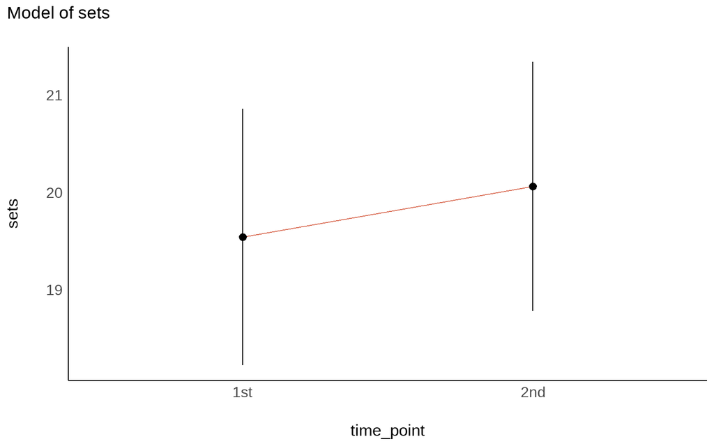

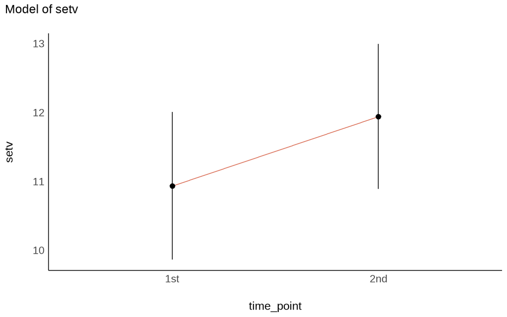

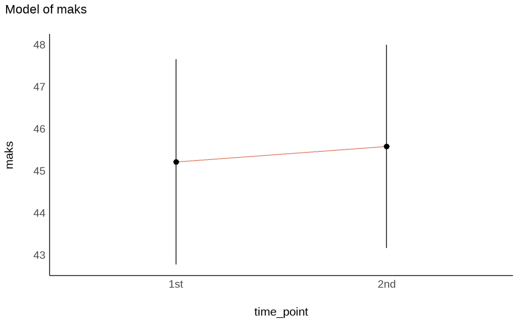

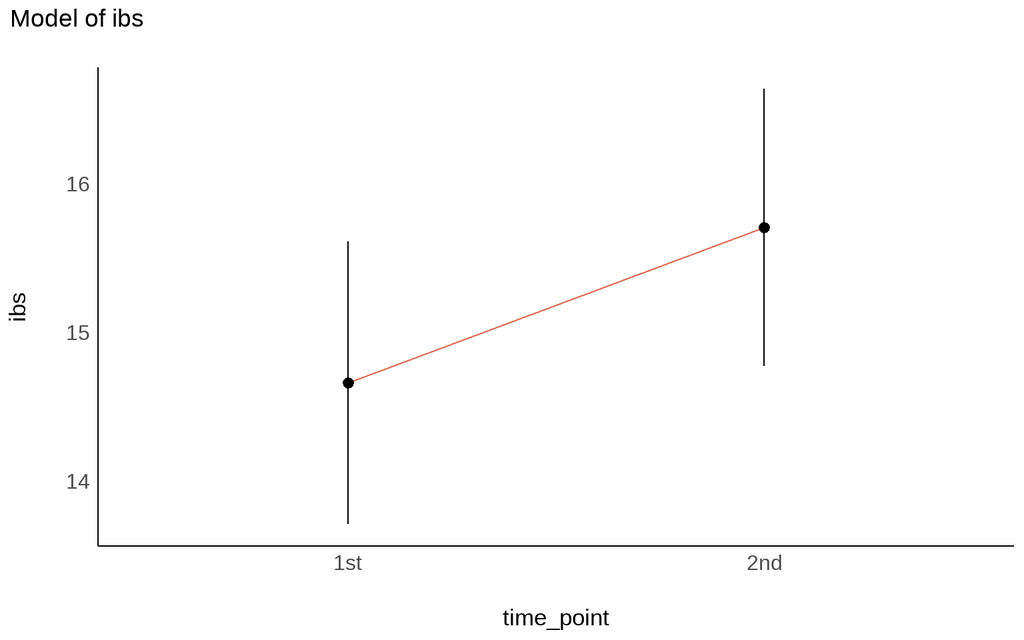

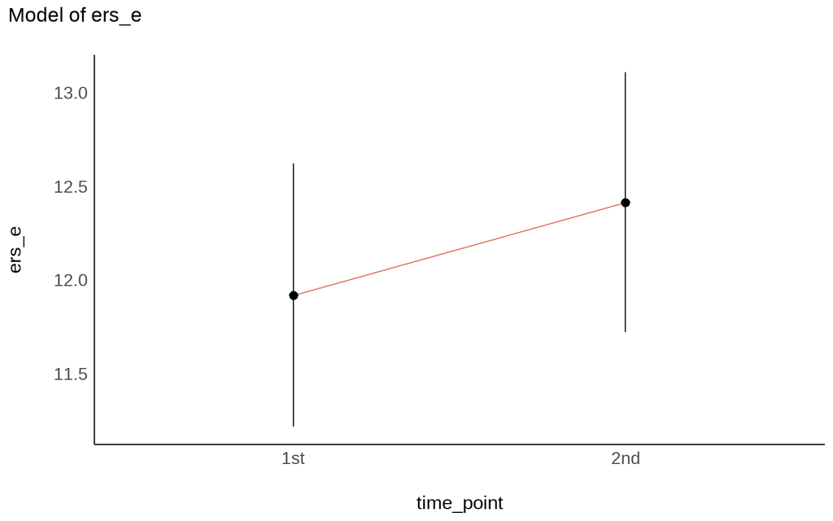

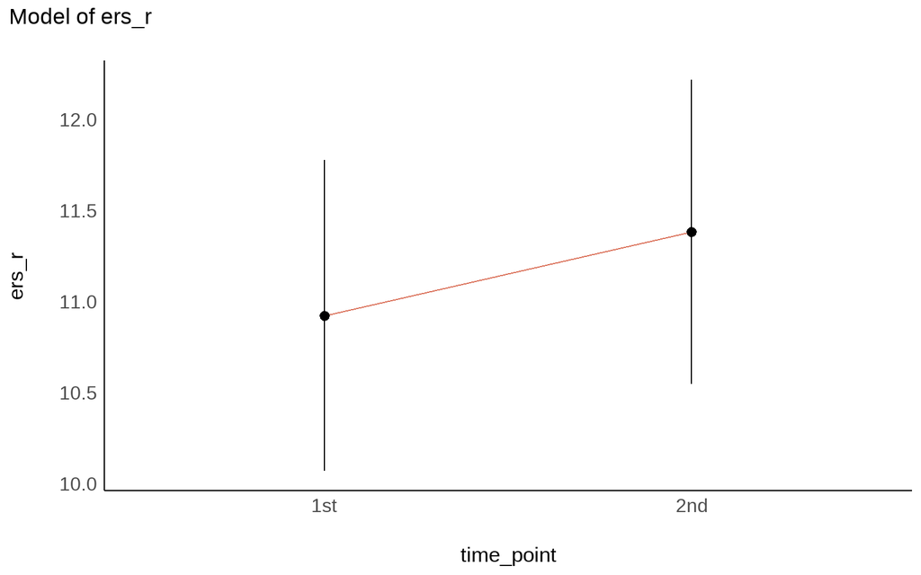

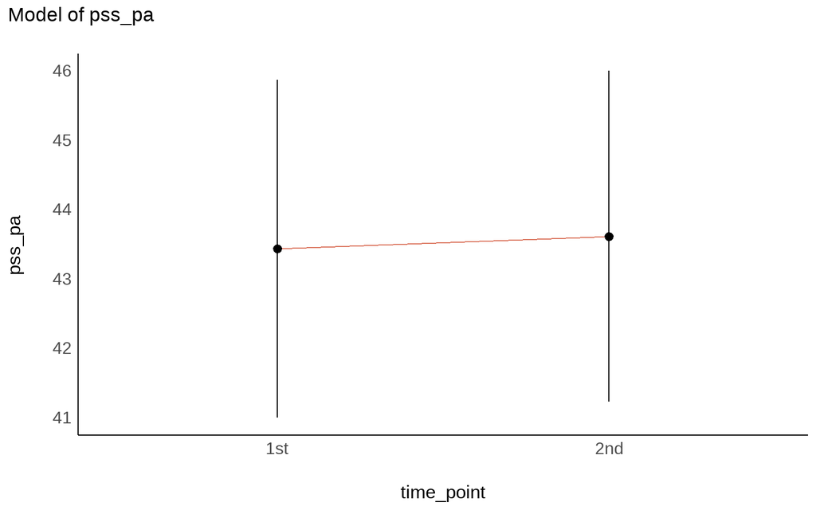

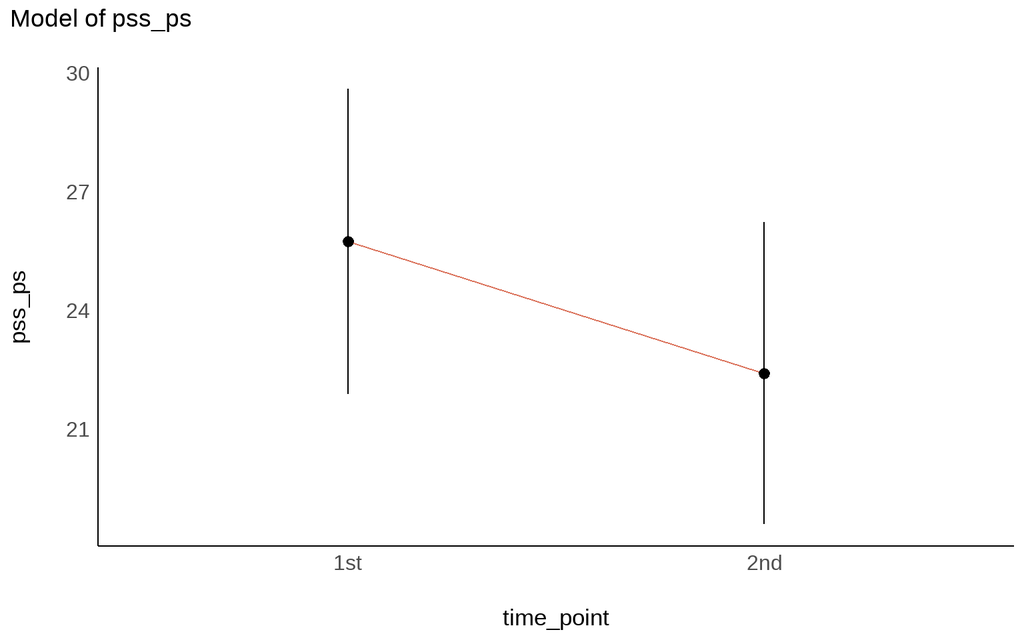

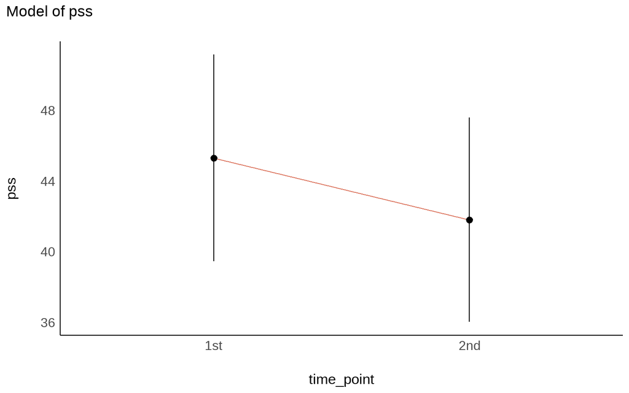

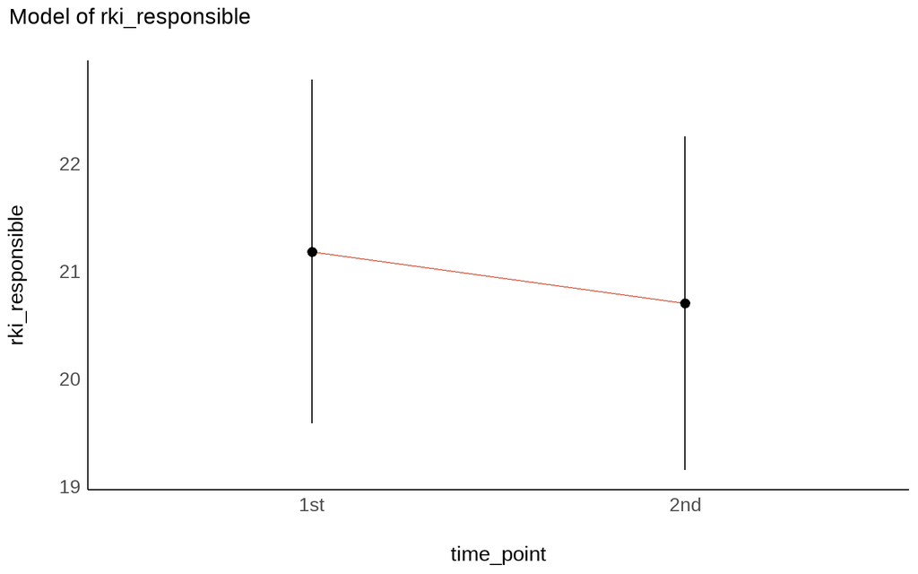

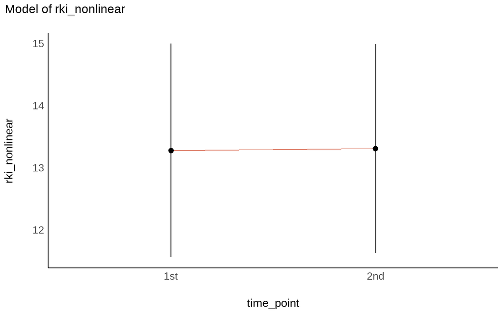

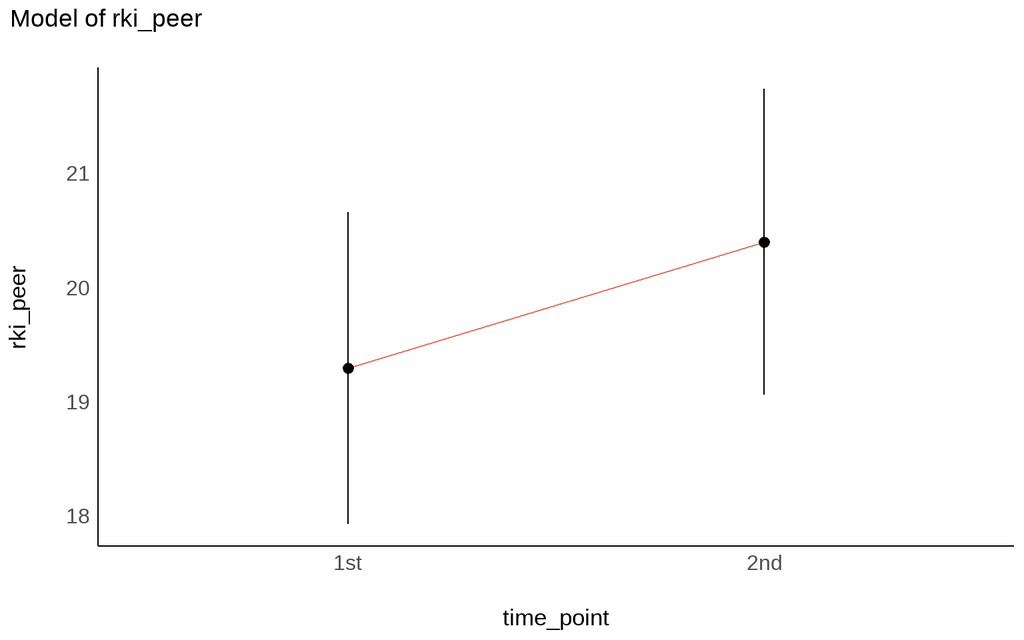

[10 more figures not shown]